# ML Hausarbeit Kunze

CV

2025-01-12

# Classification mit Bankdataset

## Einleitung

Diese Ausarbeitung befasst sich mit einem typischen *Classification* Problem aus dem Statistical Learning. Das verwendete [Datenset](https://archive.ics.uci.edu/dataset/222/bank+marketing) enthält Informationen, die im Zeitraum Mai 2008 bis November 2010 aus der Telefonmarketingkampagne einer portugiesischen Bank erhoben wurden. Ziel der Classification ist es, anhand der gegebenen Daten ein Modell zu erstellen, mit dem sich vorhersagen lässt, ob ein Kunde sich mit einem Werbetelefonat zu einem Festgeldinvestment überzeugen lassen wird, oder nicht. Dies ist für das Bankunternehmen wichtig, damit es seine Bemühungen, bzw. seine Ressourcen auf diejenigen Kunden fokussieren können, bei denen es wahrscheinlich ist, dass sie ein Investment tätigen werden.  
**Vorbereitung**  
Die benötigten Libraries werden hier geladen. Außerdem wird das CSV-File eingelesen. Um bei der Cross Validation auch reproduzierbare Ergebnisse zu erzielen, wird set.seed() verwendet.

```r
library(ggplot2)
library(boot)
library(caret)
library(dplyr)
library(tidyr)


bankdata = read.csv("bank-full.csv", TRUE, ";")
attach(bankdata)
set.seed(42)
```

## Deskriptive Statistik

### Beschreibung der Variablen

Das Set enthält **n** = 45211 Beobachtung mit **16** verschiedenen Features und **1** Response / Outputvariable, die nun kurz vorgestellt werden sollen. Dabei ist anzumerken, dass es sich nicht um 45211 verschiedene Kunden handelt, sondern mit einigen Kunden mehr als einmal Kontakt aufgebaut wurde.

```r
dim(bankdata)
```

```
## [1] 45211    17
```

**age**[integer]: Alter der Person  
**job**[categorial]: Berufliche Tätigkeit / Berufsgruppe der Person  
**marital**[categorial]: Familienstand (ledig, verheiratet, geschieden. Dabei gilt: verwitwet == geschieden)  
**education**[categorial]: Bildungsgrad (unbekannt/ *primär*, entspricht Grundschulbildung / *sekundär*, entspricht Highschool, Abitur o.ä. / *tertiär*, entpsricht Hochschulabschluss)  
**default**[binary]: Ob Kunde einer Zahlung bei einem bestehenden Kredit nicht nachkommen konnte(ja/nein)  
**balance**[integer]: Durchschnittliches jährliches Guthaben in ganzen Euro  
**housing**[binary]: Ob der Kunde ein Immobiliendarlehen aufgenommen hat (ja/nein)  
**loan**[binary]: Ob der Kunde ein persönliches Darlehen (z.B. Autokredit, Konsumkredit) aufgenommen hat (ja/nein)  
**contact**[categorial]: Art des letzten Kontakts mit dem Kunden (telefonisch, mobil, unbekannt)  
**day**[date]: Tag des letzten Kontakts im Monat  
**month**[date]: Monat des letzten Kontakts im Jahr  
**duration**[integer]: Dauer des letzten Kontakts in Sekunden  
**campaign**[integer]: Anzahl der Kontakte während dieser Marketingkampagne für diesen Kunden  
**pdays**[integer]: Anzahl der Tage seit dem letzten Kontakt in einer vorherigen Kampagne (-1 bedeutet, dass der Kunde zuvor noch nicht kontaktiert wurde)  
**previous**[integer]: Anzahl der Kontakte vor dieser Kampagne für diesen Kunden  
**poutcome**[categorial]: Ergebnis der vorherigen Marketingkampagne (erfolglos, erfolgreich, andere, unbekannt)  
**y**[binary]: Outputvariable, die vorhergesagt werden soll: Ob der Kunde ein Termingeld abgeschlossen hat (ja/nein)

*Ergänzend werden hier noch die möglichen Werte der “**job**” Variable gezeigt*

```r
unique(job)
```

```
##  [1] "management"    "technician"    "entrepreneur"  "blue-collar"
##  [5] "unknown"       "retired"       "admin."        "services"
##  [9] "self-employed" "unemployed"    "housemaid"     "student"
```

## Verteilungen

Für einige Variablen sollen nun die Verteilungen gezeigt werden. Die Variablen, bei denen es Sinn ergibt, werden kurz mit der summary()-Funktion gezeigt werden. Diese gibt die jeweiligen üblichen Kennwerte des Box-Plots und den Mittelwert einer Variable an. Variablen wie “month” werden nicht näher betrachtet. Es wäre zwar interessant zu wissen, ob Kampagnen in bestimmten Monaten signifikant besser abschneiden, die Klärung dieser Frage ist jedoch nicht Ziel dieser Ausarbeitung.

### Jobverteilung

Mit dem folgenden Chunk wird ein Balkendiagramm erstellt. Darin werden die *absoluten Häufigkeiten* der vorkommenden Berufsgruppen gezeigt und darunter werden die jeweiligen Werte geprintet. Da **job** eine *qualitative* Variable ist, muss diese vorher erst faktorisiert werden. Diese Faktorisierung wird analog auch bei den anderen qualitativen Variablen vorgenommen. Dies wird später auch bei der log. Regression wichtig, damit *R* diese Variablen auch als kategorische Werte erkennt.

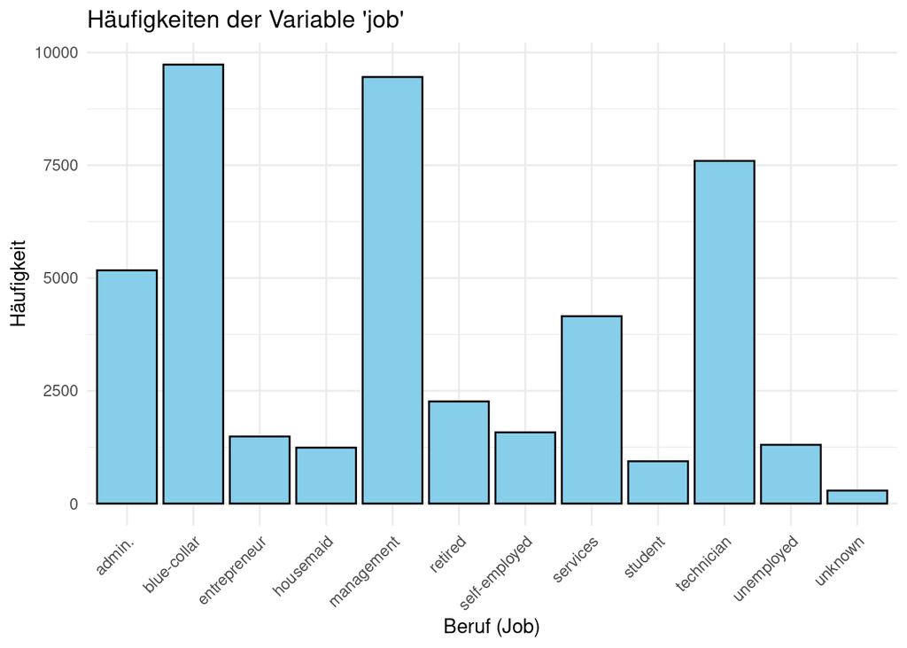

```r
bankdata$job = as.factor(bankdata$job)
ggplot(bankdata, aes(x = job)) +
  geom_bar(fill = "skyblue", color = "black") +
  labs(
    title = "Häufigkeiten der Variable 'job'",
    x = "Beruf (Job)",
    y = "Häufigkeit"
  ) +
  theme_minimal() +
  theme(axis.text.x = element_text(angle = 45, hjust = 1))
```

```r
job_häufigkeit = table(bankdata$job)
print(job_häufigkeit)
```

```
##
##        admin.   blue-collar  entrepreneur     housemaid    management
##          5171          9732          1487          1240          9458
##       retired self-employed      services       student    technician
##          2264          1579          4154           938          7597
##    unemployed       unknown
##          1303           288
```

### Altersverteilung

Balken in 5 Jahres Schritten

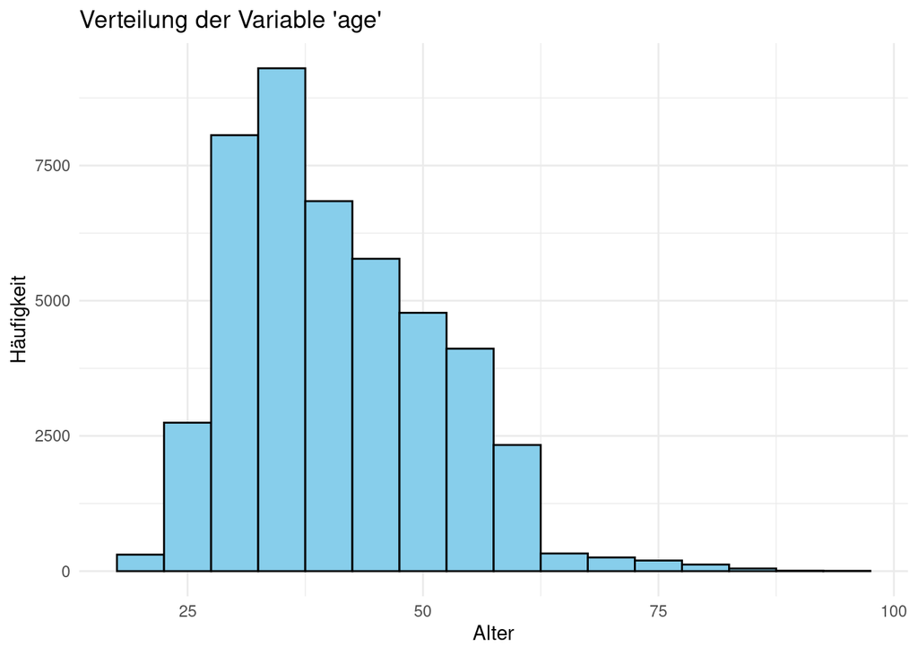

```r
ggplot(bankdata, aes(x = age)) +
  geom_histogram(binwidth = 5, fill = "skyblue", color = "black") +  # Balkenbreite auf 5 Jahre setzen
  labs(
    title = "Verteilung der Variable 'age'",
    x = "Alter",
    y = "Häufigkeit"
  ) +
  theme_minimal()
```

### Verteilung des Kontostands

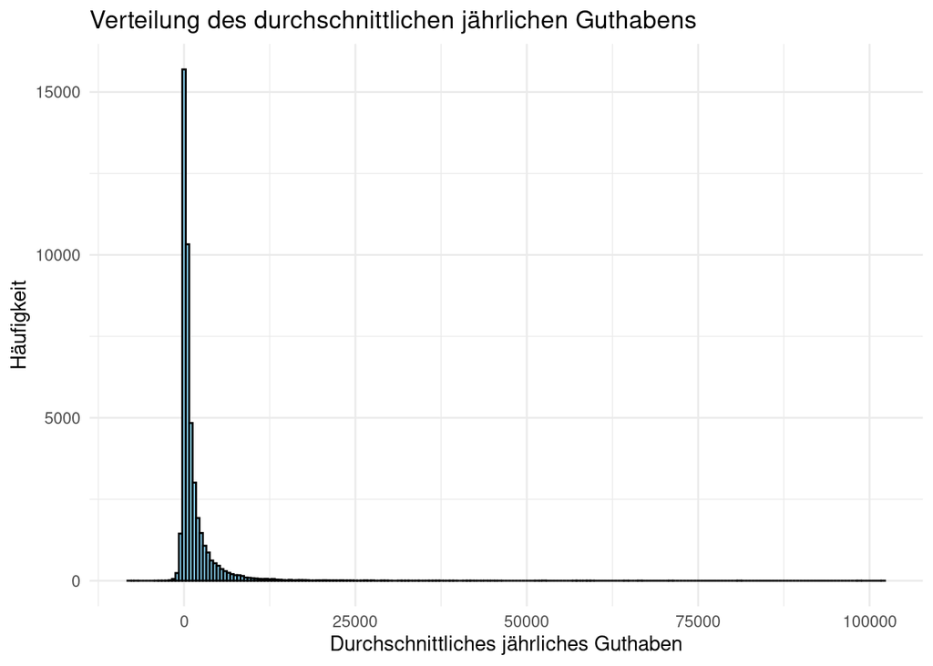

```r
ggplot(bankdata, aes(x = balance)) +
  geom_histogram(binwidth = 500, fill = "skyblue", color = "black") +
  labs(
    title = "Verteilung des durchschnittlichen jährlichen Guthabens",
    x = "Durchschnittliches jährliches Guthaben",
    y = "Häufigkeit"
  ) +
  theme_minimal()
```

### Familienstand

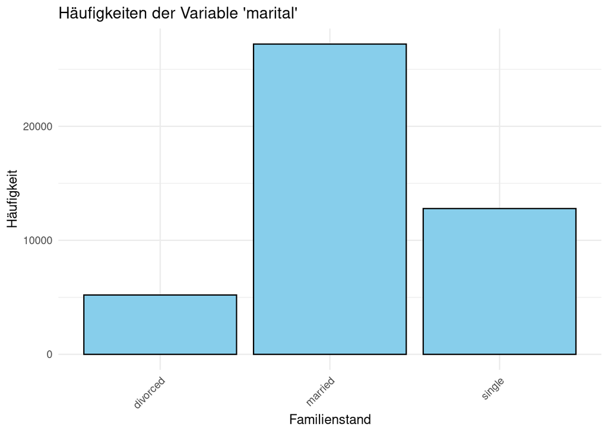

```r
bankdata$marital = as.factor(bankdata$marital)
ggplot(bankdata, aes(x = marital)) +
  geom_bar(fill = "skyblue", color = "black") +
  labs(
    title = "Häufigkeiten der Variable 'marital'",
    x = "Familienstand",
    y = "Häufigkeit"
  ) +
  theme_minimal() +
  theme(axis.text.x = element_text(angle = 45, hjust = 1))
```

```r
fam_häufigkeit = table(bankdata$marital)
print(fam_häufigkeit)
```

```
##
## divorced  married   single
##     5207    27214    12790
```

### Häufigkeit des Investments nach Werbung

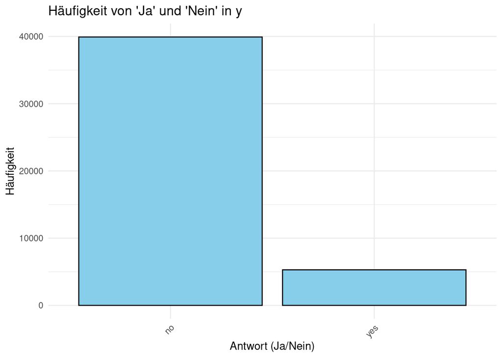

```r
bankdata$y = as.factor(bankdata$y)
ggplot(bankdata, aes(x = y)) +
  geom_bar(fill = "skyblue", color = "black") +
  labs(
    title = "Häufigkeit von 'Ja' und 'Nein' in y",
    x = "Antwort (Ja/Nein)",
    y = "Häufigkeit"
  ) +
  theme_minimal() +
  theme(axis.text.x = element_text(angle = 45, hjust = 1))
```

```r
y_häufigkeit = table(bankdata$y)
print(y_häufigkeit)
```

```
##
##    no   yes
## 39922  5289
```

### Überblick der Wertebereiche der numerischen Variablen

Hier sollen nur die Variablen betrachtet werden, bei denen es Sinn ergibt.

```r
summary(bankdata[, c("age", "balance", "duration","campaign")])
```

```
##       age           balance          duration         campaign
##  Min.   :18.00   Min.   : -8019   Min.   :   0.0   Min.   : 1.000
##  1st Qu.:33.00   1st Qu.:    72   1st Qu.: 103.0   1st Qu.: 1.000
##  Median :39.00   Median :   448   Median : 180.0   Median : 2.000
##  Mean   :40.94   Mean   :  1362   Mean   : 258.2   Mean   : 2.764
##  3rd Qu.:48.00   3rd Qu.:  1428   3rd Qu.: 319.0   3rd Qu.: 3.000
##  Max.   :95.00   Max.   :102127   Max.   :4918.0   Max.   :63.000
```

### Scatterplot - Matrix

# Statistische Verfahren

## Logistische Regression

Bevor man die logistische Regression durchführt, werden die Daten in *zufällig* ausgewählt und in ein Trainings- bzw. Testsubset geteilt. Dabei sollen 30% der Daten als Testset dienen. Damit diese “Zufälligkeit” reproduzierbar bleibt, wird set.seed(42) verwendet. Der Code bestimmt erst die Anzahl aller Einträge (n) und bestimmt dann die Trainingsgröße (0.7*n). Mit der sample() Funktion werden zufällig 70% aus der ganzen zahlen aus n gezogen und als Indizes der Trainingsdaten markiert. Anschließend werden Trainings und Testsubset durch Angabe der Indizes gebildet.

```r
set.seed(42)
n = nrow(bankdata)
train_size = floor(0.7 * n)
train_indices = sample(seq_len(n), size = train_size)

train_data = bankdata[train_indices, ]  # 70% der Daten
test_data = bankdata[-train_indices, ]  # 30%, Alle Daten, wo 1 Spalte ungleich der Zahl von denen in train_indices ist


cat("Trainingsdaten: ", nrow(train_data), "\n")
```

```
## Trainingsdaten:  31647
```

```r
cat("Testdaten: ", nrow(test_data), "\n")
```

```
## Testdaten:  13564
```

```r
bankdata$job = as.factor(bankdata$job)
bankdata$marital = as.factor(bankdata$marital)
bankdata$education = as.factor(bankdata$education)
bankdata$default = as.factor(bankdata$default)
bankdata$housing = as.factor(bankdata$housing)
bankdata$loan = as.factor(bankdata$loan)
bankdata$contact = as.factor(bankdata$contact)
bankdata$month = as.factor(bankdata$month)
bankdata$poutcome = as.factor(bankdata$poutcome)
bankdata$y = as.factor(bankdata$y)

glmfit = glm(y ~ ., data = train_data, family = binomial)
glmpredictions = predict(glmfit, newdata = test_data, type = "response")
predicted_class = ifelse(glmpredictions > 0.5, "yes", "no")
confusion_matrix = table(Predicted = predicted_class, Actual = test_data$y)
print(confusion_matrix)
```

```
##          Actual
## Predicted    no   yes
##       no  11677  1022
##       yes   296   569
```

```r
err.rate = 1-sum(diag(confusion_matrix)) / sum(confusion_matrix)
cat("Error Rate:", err.rate, "\n")
```

```
## Error Rate: 0.09716898
```

Das Modell erzielt eine Test Error Rate von insgesamt 9,7%

```r
glmfitganz = glm(y~., data = bankdata, family = binomial)
predictionsganz <- predict(glmfitganz, type = "response")
predicted_class_ganz <- ifelse(predictionsganz > 0.5, "yes", "no")
confusion_matrix_ganz <- table(Predicted = predicted_class_ganz, Actual = bankdata$y)
print(confusion_matrix_ganz)
```

```
##          Actual
## Predicted    no   yes
##       no  38940  3456
##       yes   982  1833
```

```r
err.rate = 1 -sum(diag(confusion_matrix_ganz)) / sum(confusion_matrix_ganz)
cat("Error Rate:", err.rate, "\n")
```

```
## Error Rate: 0.09816195
```

Wendet man die logistische Regression auf den gesamten Datensatz an, ergibt sich eine Error Rate von 9,8%. Dies kann ein Anzeichen von Overfitting sein.  
Vergleicht man die True Yes Rate ergibt sich eine leichte Verbesserung um 1,1 Prozentpunkte.

```r
ty_training = 569/1591
ty_ganz = 1833/5289

cat("True yes von Trainingsdaten:", ty_training,"\n")
```

```
## True yes von Trainingsdaten: 0.3576367
```

```r
cat("True Yes Rate von Gesamtset:", ty_ganz,"\n")
```

```
## True Yes Rate von Gesamtset: 0.3465683
```

```r
cat("Differenz ist Verbesserung um", ty_training,"-",ty_ganz,"=", ty_training - ty_ganz)
```

```
## Differenz ist Verbesserung um 0.3576367 - 0.3465683 = 0.01106836
```

## Cross Validation

Um die Leistungsfähigkeit des Modells besser einschätzen zu können, wenden wir auf den Datensatz nun 10-fache Kreuzvalidierung an. Dafür wird mit trainControl() erst ein Kontrollobjekt für die CV erstellt. Anschließend lässt sich ein neues Modell durch train() mit der CV trainieren. Im Mittel haben die 10 verschiedenen Validierungssets eine Vorhersage genauigkeit von 90,2% erzielt. Der Kappa-Wert ist ein Wert der Übereinstimmung zwischen den vorhergesagten und den tatsächlichen Klassen misst. Dass er bei ca. 40% liegt, weist auf eine moderate Übereinstimmung hin. Das bedeutet, dass das Modell zwar besser als eine zufällige Vorhersage abschneidet, aber noch Verbesserungspotenzial besteht.

```r
ctrl = trainControl(method = "cv", number = 10) #Kontrollobjekt, 10-Fold CV
model = train(y ~ ., data = bankdata, method = "glm", family = binomial, trControl = ctrl)
print(model)
```

```
## Generalized Linear Model
##
## 45211 samples
##    16 predictor
##     2 classes: 'no', 'yes'
##
## No pre-processing
## Resampling: Cross-Validated (10 fold)
## Summary of sample sizes: 40690, 40690, 40689, 40690, 40690, 40689, ...
## Resampling results:
##
##   Accuracy   Kappa
##   0.9016832  0.4028644
```

# Bewertung der Ergebnisse